# Week 1 - Exercise 4 - R solutions

Snorre Jallbjørn

Autumn, 2021

## Exercise 3.1 – Splitting $n \times 1$ death counts into $1 \times 1$ data

### Q.3.1

Death counts in a $n \times 1$ configuration are split into $1 \times 1$ data using cubic splines fitted to the cumulative distribution of deaths within each calendar year. In the following we will try to recreate the $1 \times 1$ death counts for Danish females in 1835.

**Question**: The dataset contains the raw input death data for Denmark. Load the data using your favourite csv reader and create a subset of the data containing only data for females in 1835.

**Solution**:

```r
HMDobj <- HMDdatClass$new(Otxtfile = 'Data/DNK_Deaths_1x1.txt', Etxtfile = 'Data/DNK_Exposures_1x1.txt')
```

```
## Imported historic data for Denmark
##   - Groups     : 2
##   - Age range  : 0 - 110
##   - Year range : 1835 - 2020
```

```r
OEdata <- HMDobj$getOEdata(agelim = c(0,110), timelim = 1835)
trueO  <- OEdata$O["Female",,]

DNK_Deaths_raw <- read.csv("Data/DNK_Deaths_raw.txt", colClasses = )
subdat <- subset(DNK_Deaths_raw, Sex == "f" & Year == 1835)
subdat$Age <- as.numeric(subdat$Age)
subdat$AgeInterval <- as.numeric(subdat$AgeInterval)

sum(subdat$Deaths)-sum(trueO) # approx 0 - so all deaths are there..
```

```
## [1] 0.01
```

### Q.3.2

Let $Y(x) = \sum_{u=0}^{x-1} D_u$ be the cumulative number of deaths up to age $x$. We assume that $Y(x)$ is known for a limited age range, including always $x =1$ and $x=5$. Our plan is to fit $Y$ with cubic splines following the equation
$$Y(x) = \alpha_0 + \alpha_1 x + \alpha_2 x^2 + \alpha_3 x^3 + \beta_1 (x-k_1)^3\mathsf{I}(x>k_1) + \dots + \beta_n (x-k_n)^3 \mathsf{I}(x>k_n),$$
where $\mathsf{I}$ denotes the indicator function and $\gamma = (\alpha_0, \dots, \alpha_3, \beta_1, \dots, \beta_n)^\top$ are parameters to be estimated. Along the age-axis we have knots $k_i, i = 1, \dots, n,$ for each observation in our dataset where we know $Y(x)$. As a matter of convention, let $k_1 = 1$ and $k_n$ be the last age with data before $\omega = 105$. Thus, we know $Y(x)$ for $n+2$ ages $x=0, k_1, \dots, k_n, \omega$, but the regression has $n+4$ parameters. We propose the following two constraints

- $Y'(\omega) = 0$,
- $Y'(1) = \frac{Y(5)-Y(1)}{2}$.

**Question**: Find $Y'(x)$ and motivate the two constraints above.

**Solution**: The first derivative of $Y$ is given by
$$Y'(x) = \alpha_1+2 \alpha_2x + 3 \beta_1(x-k_1)^2 \mathsf{I}(x-k_1)+ \dots + 3 \beta_n (x-k_n)^2 \mathsf{I}(x>k_n).$$
The first constraint is consistent with the usual tapering of the distribution of deaths at the oldest ages. However, a similar constraint at the lower boundary would not be appropriate, since deaths are highly concentrated at age 0. Instead, we constrain the slope of the function at age 1 to equal one half the increment (in cumulative deaths) between ages 1 and 5. Thus,
$$Y'(1) = \frac{Y(5) - Y(1)}{2}.$$
Since $Y'(1) \approx D(1)$, this formula is based on the observation that about half of all deaths between ages 1 and 5 tend to occur during the second year of life (at all levels of mortality).

### Q.3.3

To estimate the parameters , we can write the system on matrix form $A \gamma = b$, where $A\in\mathbb{N}_0^{(n+4) \times (n+4)}$ is the design matrix and
$$b = \left(0, Y(k_1), \dots, Y(k_n), Y(\omega), (Y(5)-Y(1))/2, 0\right)^\top$$

**Question**: Specify the design matrix $A$.

**Solution**: The design matrix is given as

$$\begin{pmatrix}
1 & 0 & 0 & 0 & 0 & 0 & \cdots & 0 & 0 \\
1 & k_1 & k_1^2 & k_1^3 & 0 & 0 & \cdots & 0 & 0 \\
1 & k_2 & k_2^2 & k_3^2 & (k_2-k_1)^3 & 0 &\cdots & 0 & 0 \\
\vdots & \vdots & \vdots & \vdots & \vdots & \vdots & \ddots & \vdots & \vdots \\
1 & k_n & k_n^2 & k_n^3 & (k_n-k_1)^3 & (k_n-k_2)^2 & \dots & (k_n-k_{n-1})^3 & 0 \\
1 & \omega & \omega^2 & \omega^3 & (\omega-k_1)^3 & (\omega-k_2)^2 & \dots & (\omega-k_{n-1})^3 & (\omega-k_n)^3 \\
0 & 1 & 2 & 3 & 0 & 0& \cdots & 0 & 0 \\
0 & 1 & 2\omega & 3 \omega^2 & 3 (\omega-k_1)^2 & 3 (\omega-k_2)^2 & \cdots & 3 (\omega-k_{n-1})^2 & 3 (\omega-k_n)^2
\end{pmatrix}$$
so that we have $A\gamma = b$, i.e.

$$\begin{pmatrix}
1 & 0 & 0 & 0 & 0 & 0 & \cdots & 0 & 0 \\
1 & k_1 & k_1^2 & k_1^3 & 0 & 0 & \cdots & 0 & 0 \\
1 & k_2 & k_2^2 & k_3^2 & (k_2-k_1)^3 & 0 &\cdots & 0 & 0 \\
\vdots & \vdots & \vdots & \vdots & \vdots & \vdots & \ddots & \vdots & \vdots \\
1 & k_n & k_n^2 & k_n^3 & (k_n-k_1)^3 & (k_n-k_2)^2 & \dots & (k_n-k_{n-1})^3 & 0 \\
1 & \omega & \omega^2 & \omega^3 & (\omega-k_1)^3 & (\omega-k_2)^2 & \dots & (\omega-k_{n-1})^3 & (\omega-k_n)^3 \\
0 & 1 & 2 & 3 & 0 & 0& \cdots & 0 & 0 \\
0 & 1 & 2\omega & 3 \omega^2 & 3 (\omega-k_1)^2 & 3 (\omega-k_2)^2 & \cdots & 3 (\omega-k_{n-1})^2 & 3 (\omega-k_n)^2
\end{pmatrix}
\begin{pmatrix}
\alpha_0 \\ \vdots \\ \alpha_3 \\ \beta_1 \\ \vdots \\ \beta_n
\end{pmatrix}
=
\begin{pmatrix}
0 \\ Y(k_1) \\ \vdots \\ Y(k_n) \\ Y(\omega) \\ (Y(5)-Y(1))/2 \\ 0
\end{pmatrix}$$

### Q.3.4

**Question**: Estimate the parameters by computing $\gamma = A^{-1} b$. Use the estimated coefficients to find fitted values $\hat{Y}(x)$ for $x = 0, 1, 2, \dots, k_n$. Estimate the $1 \times 1$ death counts by differencing
$$\hat{O}_x = \hat{Y}(x+1) - \hat{Y}(x),$$
and verify that $\hat{O}_x$ corresponds to the HMD-data in DNK_Deaths.txt (that you load with the `HMDdatClass`).

**Solution**:

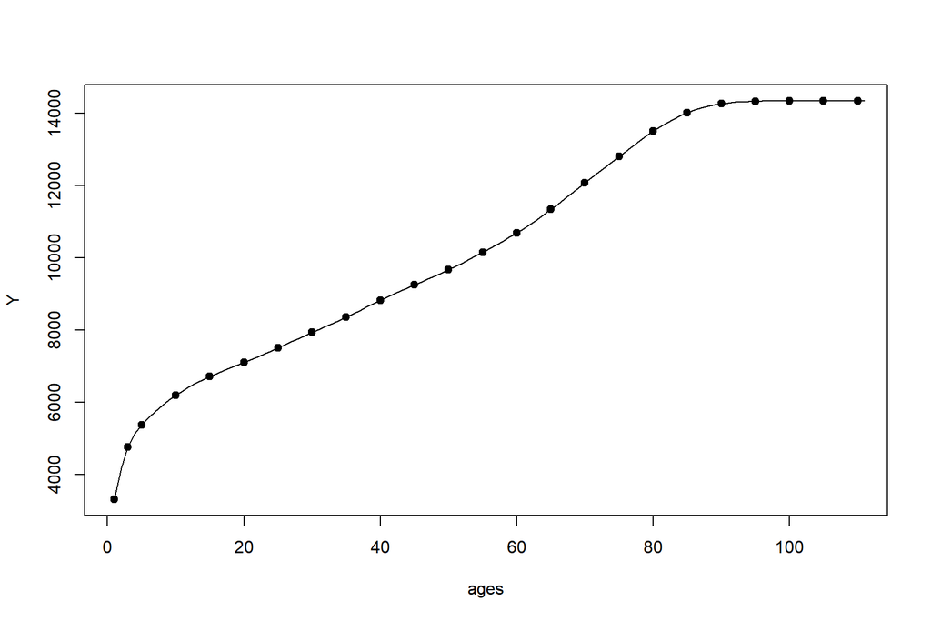

```r
###
### Cubic spline regression
###

omega <- 105
Y     <- cumsum(subdat$Deaths[-nrow(subdat)])
ages  <- subdat$Age[-nrow(subdat)] + subdat$AgeInterval[-nrow(subdat)]
plot(ages, Y, pch=19); lines(0:110+1, cumsum(trueO)) # Looks like a spline interpolation...
```

```r
Y_1 <- Y[ages == 1]
Y_5 <- Y[ages == 5]

k_n   <- c(0,ages[ages <= omega])
n     <- length(k_n)-2

# Response
b <- c(0, Y[ages <= omega], (Y_5-Y_1)/2, 0)

# Design matrix
A <- matrix(0, nrow = n+4, ncol = n+4)
rowIdx <- 1:(n+2)
A[rowIdx,1] <- k_n^0
A[rowIdx,2] <- k_n^1
A[rowIdx,3] <- k_n^2
A[rowIdx,4] <- k_n^3
for (j in 5:ncol(A)) {
    nIdx <- j-3
    A[rowIdx,j] <- c(rep(0, nIdx), (k_n[-(1:nIdx)] - k_n[nIdx])^3)
}
A[n+3,] <- c(0:3, rep(0, n))
A[n+4,] <- c(0,1,2*omega,3*(omega-k_n[-length(k_n)])^2)

# Coefficients
gamma <- solve(A, b)

# Spline fun.
Y.x <- function(x, gamma) {
    xminusk <- x - k_n[-c(1,length(k_n))]
    c(1, x, x^2, x^3, ifelse(xminusk > 0, xminusk^3, 0)) %*% gamma
}

xvec <- 0:(k_n[length(k_n)-1]+1)
estO <- diff(sapply(xvec, function(x) Y.x(x, gamma)))

cbind("Estimate" = round(estO,2), "HMD" = trueO[1:(length(xvec)-1)], "Diff" =  round(estO,2)-trueO[1:(length(xvec)-1)])
```

```
##     Estimate     HMD  Diff
## 0    3315.00 3315.00  0.00
## 1     865.93  865.94 -0.01
## 2     582.07  582.06  0.01
## 3     366.21  366.21  0.00
## 4     242.79  242.79  0.00
## 5     202.00  202.00  0.00
## 6     180.12  180.12  0.00
## 7     161.22  161.22  0.00
## 8     145.30  145.29  0.01
## 9     132.36  132.36  0.00
## 10    122.01  122.01  0.00
## 11    112.68  112.68  0.00
## 12    103.97  103.98 -0.01
## 13     95.90   95.90  0.00
```

[output cut: 87 more lines]

### Q.3.5

**Question**: The spline method described above does not guarantee that $\hat{Y}$ is monotonically increasing over all ages. Why is this problematic? When would this problem typically occur in practice?

**Solution**: Since the curve depicts the cumulative deaths over age, a decreasing function between ages $x$ and $x+1$ implies negative death counts at age $x$. The problem is likely most pronounced at the oldest ages where data is sparse and more unreliable. For this reason, HMD uses a different method for splitting deaths from an open age interval into finer categories.